# Theory of Computation

Reagan Shirk

September 3, 2019

# Something about LaTeX

- It’s pronounced latec, not latex. Fun stuff.
- Tutorial on how to compile a latex document and ouput to a pdf
- Sorry for the bad notes for this, I do latex through RStudio so I didn’t super pay attention
- to anyone who actually looks at my notes, pls stop talking (or get your friends to stop talking) during lecture, ya girl as tinnitus and can’t hear shit :)

# Formal Definition for NFAs

- An NFA (nondeterministic finite automaton/accepter) is defined by a 5-tuple ($Q$, $\Sigma$, $\delta$, $q_o$, $F$) where $Q$ is a finite alphabet, $q_o$ is a staring state, $F$ is a set of accepting states, and $\delta$ is a transition state equal to $(Q \times \Sigma) \cup \left\{\lambda\right\} \to P(Q)$
- $Q, \Sigma, q_o, F$ are all the same as DFAs
  - $\delta$: $A \times \Sigma \to Q$ is the case for DFAs

# NFA Example, $\Sigma_{\lambda} = \left\{0, 1, \lambda\right\}$

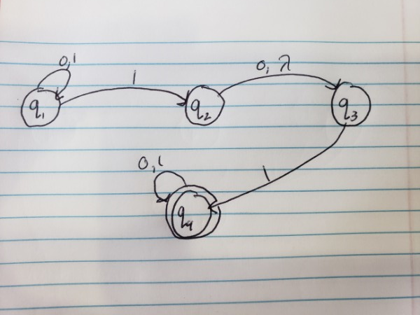

State Diagram

- As long as you consume the lambdas consistently you don’t have to…organize? I can’t hear
  - And in retrospect I have no idea what this means

# Proof

- Definition: Two machine are equivalent iff they recognize the same language. In other words: $L(M_1) = L(M_2)$
- Theorem: Every NFA has an equivalent DFA
- Proof idea: Create DFA $M$ that simulates the behavior of NFA $N$. At any point in time we need to keep track on $M$ of all of the states where $N$ is currently at ($N$ has a copy of itself in one of these states). All we need to do is define the 5-tuple
- Actual proof:
  - Assume for know as lambda transitions
    - $Q_m = P(Q_n)$
      - We need one state in $M$ for every one of the $2^Q$ subsets in $N$.
    - $\Sigma_m = \Sigma_n$
    - $q_{om} = q_{on}$
    - $F_m = \left\{R \in P(Q) | \exists~r \in R~and~r \in F_n\right\}$